# Review and Trend Analysis of Knowledge Graphs for Crop Pest and Diseases | IEEE Journals & Magazine | IEEE Xplore

# Review and Trend Analysis of Knowledge Graphs for Crop Pest and Diseases

Publisher: IEEE

[Liu Xiaoxue](https://ieeexplore.ieee.org/author/37086840548); [Bai Xuesong](https://ieeexplore.ieee.org/author/37991044900); [Wang Longhe](https://ieeexplore.ieee.org/author/37086840379); [Ren Bingyuan](https://ieeexplore.ieee.org/author/37086841430); [Lu Shuhan](https://ieeexplore.ieee.org/author/37086840399); [Li Lin](https://ieeexplore.ieee.org/author/37086841329)

Open Access

**Abstract:**

Current techniques of knowledge management have some common defects in efficiency, scalability, and applicability. Knowledge graph provides a new way for knowledge management and is a more flexible knowledge management method. Considering the specific features of crop diseases and pest data, this paper analyzed and classified the key techniques and methods of knowledge graph technology in the field of crop diseases and pest in recent years. We introduced the definition and connotation of the crop diseases and pest knowledge, and the current construction method of it was analyzed in detail from four aspects: knowledge representation, extraction, fusion, and reasoning. Furthermore, the application of crop diseases and pest knowledge graph was introduced in detail in the expert system, search engine, and knowledge question-answering system. At last, this paper summarized the challenges and important problems of diseases and pest knowledge graph and forecasted the prospect of knowledge graph according to the key points and difficulties of current knowledge graph research.

**Published in:** [IEEE Access](https://ieeexplore.ieee.org/xpl/RecentIssue.jsp?punumber=6287639) ( Volume: 7)

**Page(s):** 62251 - 62264

**Date of Publication:** 09 May 2019

**Electronic ISSN:** 2169-3536

**INSPEC Accession Number:** 18687513

**DOI:** 10.1109/ACCESS.2019.2915987

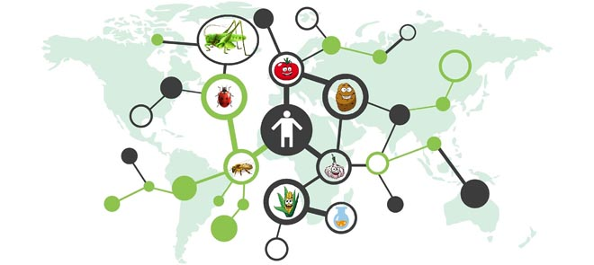

SECTION I.

## Introduction

A knowledge graph is a structured semantic knowledge base that describes concepts and their relationships in the physical world in the form of symbols. It allows knowledge representation and management to solve knowledge association problems, such as knowledge retrieval and semantic question answering. It is the basis and bridge to realize intelligent semantic retrieval [1]. Knowledge graph technology is a combination of ontology technology, knowledge extraction, fusion, query, storage, reasoning, and other technologies. It can be divided into general and vertical domain knowledge graphs. Generally, a knowledge graph is typically large-scale, in wide field, and has large amount of common sense [2]. The vertical domain knowledge graph has desirable advantages of accuracy and fine granularity, and can effectively support knowledge reasoning and knowledge retrieval applications. Crop diseases and insect pests have a vertical industry knowledge graph, which is one of the most widely used fields. Knowledge graph technology for crop pests and diseases has been widely applied for crop variety selection [3], greenhouse environment control, pest control [4], fertilization and irrigation [5], economic benefit analysis [6], and other aspects of agricultural production and application. Developing pest and disease expert systems based on knowledge graphs have promoted the conversion of achievements of agricultural technology, contributing to the development of high-yield, high-efficiency and high-quality agriculture [7].

In the field of crop diseases and insect pests, the traditional knowledge bases based on the experience of experts in the field are static and limited. However, data for agricultural production and research on diseases and insect pest are huge. Full and effective sharing and integration of pest and disease data is the basis of semantic interoperability. Expert knowledge of pests and diseases is represented by text, tables, and figures, but these need to be converted into computational resources and processed by computers; therefore, a large-scale and open-linked knowledge acquisition and management method of pests and diseases based on knowledge graph technology has emerged [8]. Knowledge graph construction includes extracting entities, relationships, and attributes from structured, semi-structured, and unstructured data; integrating knowledge through entity alignment and ontology matching; and evaluating the quality of the knowledge base, and then updating, completing, and retrieving knowledge [9]. The methods and technologies used in knowledge representation, extraction, fusion, and reasoning are reviewed based on the construction of knowledge graphs in the field of crop diseases and insect pests. Future developments in knowledge graph construction technology and their applications in the crop are prospected in this paper.

The main organization structure of this paper is as follows: Section 1 briefly introduces the current knowledge graph and the knowledge graph of crop diseases and insect pests. Section 2 introduces the definition and structure of knowledge graph, and gives examples of field of crop diseases and insect pests for illustration. Section 3 introduces the main technologies and methods in the knowledge graph construction of crop diseases and insect pests, which are divided into four parts: knowledge representation, knowledge extraction, knowledge fusion and knowledge reasoning. Section 4 introduces some applications of knowledge graph of crop diseases and insect pests, such as expert system, intelligent search and question answering system. Finally, the prospect of knowledge graph of crop diseases and insect pests is presented.

SECTION II.